[figure not shown]

# Análise sobre os atendimentos da PMSC

## Município de Florianópolis

Objetivo específico desta análise:

- Observar o volume das ocorrências ao longo do tempo
- Compreender como as ocorrências são reportadas e quais geram atendimentos
- Verificar o tempo médio, e o volume de tempo investido pela PM em cada classificação de atendimento

[Página anterior](https://igarape-inc.github.io/asc/analise_ocorrencias_criciuma.html) | [Página inicial](https://igarape-inc.github.io/asc/intro.html) | [Próxima página](https://igarape-inc.github.io/asc/nivel_3_cr.html)

## Origem dos registros das ocorrências

Uma ocorrência pode ter as seguintes origens registradas no banco de dados:

- Telefone (cidadão informou via telefone 190)
- Direto à guarnição (cidadão informou direto à guarnição)
- Guarnição se deparou
- Videomonitoramento (câmeras de videomonitoramento)
- 190 acessível (aplicativo da PMSC para pessoas com deficiência autidiva)

A próxima tabela indica a proporção de registros relativos a cada código de origem.

```
Total de ocorrências no período: 1700563
```

|  | Descrição | contagem | % |
| --- | --- | --- | --- |
| 0 | Telefone | 1613958 | 98.14 |
| 1 | Guarnição se deparou | 17823 | 1.08 |
| 2 | Direto à guarnição | 12185 | 0.74 |
| 3 | Videomonitoramento | 459 | 0.03 |
| 4 | 190 acessível | 201 | 0.01 |

## Categorias de chamadas ao 190

A tabela abaixo demonstra a proporção de chamadas ao 190, por categoria.

A categoria de cada chamada é definida pelo atendente do COPOM. Existem sete opções de categorias.

```
Total de chamadas ao 190 - jan/2016 a maio/2019 1633922
```

| ID | categoria | contagem | % |
| --- | --- | --- | --- |
| 11 | Ligação interrompida | 1004300 | 61.47 |
| 1 | Ocorrência | 406264 | 24.86 |
| 6 | Informação | 137339 | 8.41 |
| 7 | Trote | 69509 | 4.25 |
| 10 | Engano | 15229 | 0.93 |
| 8 | Elogio | 932 | 0.06 |
| 5 | Denúncia | 349 | 0.02 |

```
n_total = 1633922
```

[interactive chart not shown]

## Ligações interrompidas que geraram atendimento

A seguir temos todas as ocorrências registradas com:

- ID_CATEGORIA registrado como *Ligação interrompida* (código 11), e
- ID_GUARNICAO não-nulo

Em Florianópolis, foram apenas cinco ocorrências com ligação interrompida que geraram atendimento desde 2016.

|  | ID_ATENDIMENTO | ID_CATEGORIA | DATA_HORA_FATO | classificação atendimento | ID_CODIGO_FECHAMENTO |
| --- | --- | --- | --- | --- | --- |
| 410732 | 5005045629.00 | 11.00 | 2016-06-18 00:57:13 | Inválido | 21.00 |
| 472237 | 5005422750.00 | 11.00 | 2016-08-29 15:32:19 | Inválido | 21.00 |
| 481040 | 5005172182.00 | 11.00 | 2016-07-12 04:53:53 | Inválido | 21.00 |
| 624238 | 5005973895.00 | 11.00 | 2016-12-09 17:16:27 | Dano simples | 1.00 |
| 1069273 | 5007574556.00 | 11.00 | 2018-01-02 09:22:58 | Inválido | 21.00 |

## Volume de *atendimentos* por classificação de atendimento - 2018

No gráfico abaixo, verificam-se os registros que geraram atendimento policial:

- Registros que tiveram ID_ATENDIMENTO_UNIDADE (ou seja que este campo na base de dados não consta como nulo); e
- que *não tiveram* código de fechamento CF16 - Falta de Patrulha

O gráfico apresenta as 50 classificações de atendimento mais atendidas pela PM em 2018.

*Clique e arraste o gráfico para dar zoom e ver o nome completo da classificação de atendimento. Duplo-clique para retornar ao zoom original.*

```
Total de antendimentos em 2018 = 463138
```

[interactive chart not shown]

## Volume diário de ocorrências registradas

O gráfico a seguir apresenta o volume diário de todos as ocorrências registradas.

*Clique e arraste no gráfico para dar zoom. Clique duas vezes em qualquer ponto do gráfico para voltar ao zoom original.*

```
TOTAL DE OCORRÊNCIAS ENTRE 1/JAN/2016 E 28/MAIO/2019:
1700563
```

[interactive chart not shown]

```
TOTAL DE OCORRÊNCIAS INVÁLIDAS ENTRE 1/JAN/2016 E 28/MAIO/2019:
1257141
```

[interactive chart not shown]

```
TOTAL DE OCORRÊNCIAS VÁLIDAS ENTRE 1/JAN/2016 E 28/MAIO/2019:
443422
```

[interactive chart not shown]

## Origem e desfecho das ocorrências inválidas - ano de 2018

São consideradas inválidas as ocorrências que tiveram:

- ID_TIPO_ATENDIMENTO inválido (código 42), ou
- ID_CODIGO_FECHAMENTO inválido (código 24), ou
- ID_CLASSIFICACAO_ATENDIMENTO inválido (código 1293)

```
Origem das ocorrências inválidas - 2018
n° total de ocorrências = 347089
```

| Descrição | contagem | % |
| --- | --- | --- |
| Telefone | 339013 | 97.67 |
| Registro nulo | 7883 | 2.27 |
| Direto à guarnição | 98 | 0.03 |
| Guarnição se deparou | 76 | 0.02 |
| Videomonitoramento | 12 | 0.00 |
| 190 acessível | 7 | 0.00 |

```
ID_CATEGORIA das ocorrências inválidas - 2018
n° total de ocorrências = 347089
```

| ID | categoria | contagem | % |
| --- | --- | --- | --- |
| 11 | Ligação interrompida | 209500 | 60.36 |
| 6 | Informação | 67548 | 19.46 |
| 7 | Trote | 54515 | 15.71 |
| 1 | Ocorrência | 7875 | 2.27 |
| 10 | Engano | 7249 | 2.09 |
| 8 | Elogio | 395 | 0.11 |
| 5 | Denúncia | 7 | 0.00 |

```
Classificação de atendimento das ocorrências inválidas - 2018
n° total de ocorrências = 347089
```

|  | ID | contagem | % | classificação atendimento |
| --- | --- | --- | --- | --- |
| 0 | 1293.00 | 347080 | 100.00 | Inválido |
| 1 | 1345.00 | 5 | 0.00 | Estacionar o veículo em desacordo com as condições regulamentadas |
| 2 | 158.00 | 2 | 0.00 | Averiguação de pessoa em atitude suspeita |
| 3 | 114.00 | 1 | 0.00 | Perturbação do trabalho ou sossego alheio |
| 4 | 170.00 | 1 | 0.00 | Crime ambiental contra a Flora |

```
Código de fechamento das ocorrências inválidas - 2018
n° total de ocorrências = 347089
```

| Descrição | contagem | % |
| --- | --- | --- |
| Inválido | 340823 | 98.19 |
| Ocorrência duplicada | 6250 | 1.80 |
| Notícia de Infração Penal Ambiental | 9 | 0.00 |
| Atendimento encaminhado para o BPMRv | 1 | 0.00 |
| Atendimento encaminhado para o P2 da OPM | 1 | 0.00 |
| Atendimento encerrado automaticamente após 48 horas de sua criação | 1 | 0.00 |
| BO-AT: Acidente de Trânsito | 1 | 0.00 |
| Comunicação de Ocorrência Policial | 1 | 0.00 |
| Fato sem informações para registro | 1 | 0.00 |

## Ocorrências inválidas que tiveram atendimento

São contabilizadas, à seguir, as ocorrências inválidas que tiveram atendimento de alguma guarnição - ou seja, ocorrências com ID_CLASSIFICACAO_ATENDIMENTO inválido e ID_GUARNICAO não-nulo.

```
n° total de ocorrências inválidas que tiveram atendimento em 2018 = 999
```

```
Código de fechamento das ocorrências inválidas  que tiveram atendimento - 2018
n° total de ocorrências = 999
```

| Descrição | contagem | % |
| --- | --- | --- |
| Ocorrência duplicada | 717 | 71.77 |
| Inválido | 275 | 27.53 |
| Notícia de Infração Penal Ambiental | 3 | 0.30 |
| Atendimento encaminhado para o BPMRv | 1 | 0.10 |
| BO-AT: Acidente de Trânsito | 1 | 0.10 |
| Comunicação de Ocorrência Policial | 1 | 0.10 |
| Fato sem informações para registro | 1 | 0.10 |

```
Código de fechamento das ocorrências inválidas  que tiveram atendimento - 2018
n° total de ocorrências = 999
```

| Descrição | contagem | % |
| --- | --- | --- |
| Ocorrência duplicada | 717 | 71.77 |
| Inválido | 275 | 27.53 |
| Notícia de Infração Penal Ambiental | 3 | 0.30 |
| Atendimento encaminhado para o BPMRv | 1 | 0.10 |
| BO-AT: Acidente de Trânsito | 1 | 0.10 |
| Comunicação de Ocorrência Policial | 1 | 0.10 |
| Fato sem informações para registro | 1 | 0.10 |

## Análise das chamadas sem atendimento

Uma chamada ao 190, mesmo sendo válida, pode não receber o atendimento da polícia.

Na base de dados, uma chamada sem atendimento pode ser registrada de duas maneiras (i) com o ID_ATENDIMENTO_UNIDADE nulo, indicando que não houve despacho pelo COPOM, ou (ii) com o código de fechamento da ocorrência "CF16 - Falta de Patrulha", indicando que houve despacho do COPOM, mas que a Unidade da PM responsável não foi capaz de prestar o atendimento.

**Para certificar-se de que todas as chamadas sem atendimento foram contabilizadas, verificou-se que:**

- Dentre as chamadas com ID_ATENDIMENTO_UNIDADE nulo, nenhuma tem ID_ATENDIMENTO duplicado √
- Quando o ID_ATENDIMENTO_UNIDADE é nulo, o ID_ATENDIMENTO_ENCERRAMENTO também é nulo √
- Quando o ID_ATENDIMENTO_UNIDADE é nulo, o ID_CODIGO_FECHAMENTO também é nulo √
- Todas as chamadas no banco têm ao menos uma classificação de atendimento registrada √

```
Número de chamadas sem ID_ATENDIMENTO:
```

```
0
```

```
Número e porcentagem de chamadas sem ID_ATENDIMENTO_UNIDADE:
25578
1.56 %
```

```
Número de chamadas com ID_ATENDIMENTO_UNIDADE nulo, e ID_ATENDIMENTO duplicado:
```

```
0
```

```
Número de chamadas sem ID_ATENDIMENTO_UNIDADE, porém com ID_ATENDIMENTO_ENCERRAMENTO:
```

```
0
```

```
Número de chamadas sem ID_ATENDIMENTO_UNIDADE, porém com ID_CODIGO_FECHAMENTO:
```

```
0
```

```
Numero de chamadas sem classificação de atendimento:
```

```
0
```

**Ocorrências com ID_ATENDIMENTO_UNIDADE nulo**

A tabela a seguir lista todas as ocorrências com ID_ATENDIMENTO registrado, porém sem ID_ATENDIMENTO_UNIDADE (possívelmente indicando que não houve despacho pelo COPOM).

```
Total de ocorrências de jan/2016 a maio/2019: 1700563

Total de ocorrências sem ID_ATENDIMENTO_UNIDADE: 25208
```

|  | ID | contagem | % | classificação atendimento |
| --- | --- | --- | --- | --- |
| 0 | 1294.00 | 25155 | 99.79 | SAMU |
| 1 | 1293.00 | 30 | 0.12 | Inválido |
| 2 | 114.00 | 4 | 0.02 | Perturbação do trabalho ou sossego alheio |
| 3 | 268.00 | 3 | 0.01 | Acidente de trânsito apenas danos materiais |
| 4 | 13.00 | 3 | 0.01 | Vias de fato |
| 5 | 158.00 | 2 | 0.01 | Averiguação de pessoa em atitude suspeita |
| 6 | 3097.00 | 2 | 0.01 | Averiguação de pessoa em atitude suspeita |
| 7 | 159.00 | 1 | 0.00 | Outras averiguações |
| 8 | 3055.00 | 1 | 0.00 | Ameaça |
| 9 | 269.00 | 1 | 0.00 | Acidente de trânsito com Vítima |
| 10 | 362.00 | 1 | 0.00 | Apoio |
| 11 | 3657.00 | 1 | 0.00 | Posse ou porte ilegal de arma de fogo de uso restrito |
| 12 | 57.00 | 1 | 0.00 | Furto |
| 13 | 63.00 | 1 | 0.00 | Posse de drogas |
| 14 | 359.00 | 1 | 0.00 | Cumprimento de mandado de busca e apreensão |
| 15 | 117.00 | 1 | 0.00 | Atrito verbal ou discussão |

**Ocorrências com código de fechamento "falta de patrulha":**

A tabela e gráfico abaixo listam as ocorrências que têm registro de um ID_ATENDIMENTO_UNIDADE, porém com o código de fechamento **CF16 - Falta de patrulha**.

```
Número de ocorrências com código de fechamento "Falta de patrulha": 18778

Porcentagem de ocorrências com código de fechamento "Falta de patrulha": 1.15 %
```

|  | ID | contagem | % | classificação atendimento |
| --- | --- | --- | --- | --- |
| 0 | 114.00 | 12117 | 64.53 | Perturbação do trabalho ou sossego alheio |
| 1 | 1345.00 | 1389 | 7.40 | Estacionar o veículo em desacordo com as condições regulamentadas |
| 2 | 159.00 | 862 | 4.59 | Outras averiguações |
| 3 | 158.00 | 672 | 3.58 | Averiguação de pessoa em atitude suspeita |
| 4 | 1357.00 | 365 | 1.94 | Estacionar o veículo impedindo a movimentação de outro veículo |
| 5 | 3631.00 | 304 | 1.62 | Perturbação do trabalho ou sossego alheios |
| 6 | 1836.00 | 270 | 1.44 | Averiguação em residência ou comércio |
| 7 | 117.00 | 250 | 1.33 | Atrito verbal ou discussão |
| 8 | 3630.00 | 208 | 1.11 | Perturbação da tranquilidade |
| 9 | 25.00 | 207 | 1.10 | Ameaça |
| 10 | 13.00 | 191 | 1.02 | Vias de fato |
| 11 | 63.00 | 173 | 0.92 | Posse de drogas |
| 12 | 1341.00 | 155 | 0.83 | Outras Infrações de Trânsito |
| 13 | 1835.00 | 125 | 0.67 | Averiguação de veículo suspeito |
| 14 | 62.00 | 123 | 0.66 | Tráfico de drogas |

```
Número de ocorrências com código de fechamento "Falta de patrulha": 18778
```

[interactive chart not shown]

```
Número de ocorrências de PERTURBAÇÃO sem atendimento por falta de patrulha: 12629
```

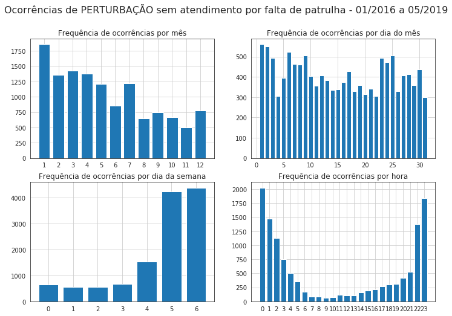

```
Número de ocorrências de (EXCLUINDO PERTURBAÇÃO) sem atendimento por falta de patrulha: 6149
```

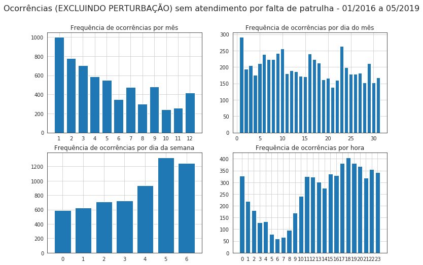

**Ocorrências com código de fechamento "falta de patrulha", por ID_UNIDADE:**

A tabela abaixo lista as ocorrências registradas com o código de fechamento **CF16 - Falta de patrulha**, por Unidade da PM.

```
Total de ocorrências com CF16 - 01/2016 a 05/2019: 18778
```

|  | ID_UNIDADE | total de ocorrências da unidade | nº ocorrências CF16 | % CF16 |
| --- | --- | --- | --- | --- |
| 0 | 783 | 1314576 | 1302 | 0.10 |
| 1 | 785 | 116242 | 6666 | 5.73 |
| 2 | 786 | 78613 | 5365 | 6.82 |
| 3 | 813 | 71552 | 2106 | 2.94 |
| 4 | 787 | 59130 | 2237 | 3.78 |
| 5 | 820 | 25216 | 799 | 3.17 |
| 6 | 826 | 4554 | 256 | 5.62 |
| 7 | 340 | 1565 | 9 | 0.58 |
| 8 | 219 | 813 | 6 | 0.74 |
| 9 | 1022 | 776 | 0 | 0.00 |
| 10 | 858 | 708 | 23 | 3.25 |
| 11 | 855 | 491 | 6 | 1.22 |
| 12 | 1110 | 411 | 2 | 0.49 |
| 13 | 1190 | 239 | 0 | 0.00 |
| 14 | 831 | 83 | 1 | 1.20 |

## Códigos de fechamento

A PMSC tem uma série de códigos para descrever o fechamento de uma ocorrência. A tabela abaixo indica a proporção de registros relativos a cada código de fechamento:

```
Total de ocorrências no período - 01/2016 a 05/2019: 1700563
```

|  | Descrição | ID_CODIGO_FECHAMENTO | contagem | % |
| --- | --- | --- | --- | --- |
| 0 | Inválido | 21 | 1232064 | 73.55 |
| 1 | Ocorrência Inexistente | 9 | 88692 | 5.29 |
| 2 | Fato sem informações para registro | 14 | 60943 | 3.64 |
| 3 | Resolvido no local | 12 | 57331 | 3.42 |
| 4 | Comunicação de Ocorrência Policial | 1 | 31812 | 1.90 |
| 5 | Averiguação Policial sem Alteração | 10 | 29482 | 1.76 |
| 6 | Atendimento dispensado pelo solicitante | 13 | 29124 | 1.74 |
| 7 | Ocorrência duplicada | 15 | 22932 | 1.37 |
| 8 | Prisão/Apreensão | 2 | 20332 | 1.21 |
| 9 | Falta de patrulha | 16 | 18778 | 1.12 |
| 10 | BO-AT: Acidente de Trânsito | 4 | 17703 | 1.06 |
| 11 | Registro de Ocorrência | 8 | 12657 | 0.76 |
| 12 | Atendimento encaminhado para o BPMRv | 19 | 10775 | 0.64 |
| 13 | Termo Circunstanciado | 3 | 10613 | 0.63 |
| 14 | Atendimento encaminhado a outros órgãos | 20 | 10172 | 0.61 |
| 15 | Atendimento transmitido à Rede de Rádio | 23 | 8674 | 0.52 |
| 16 | Providências Administrativas de Trânsito Adotadas | 11 | 5387 | 0.32 |
| 17 | BO-AT/TC: Acidente de Trânsito/TC | 5 | 2936 | 0.18 |
| 18 | Atendimento encaminhado para o P2 da OPM | 18 | 1826 | 0.11 |
| 19 | BO-AT/COP: Acidente de Trânsito/COP | 7 | 914 | 0.05 |
| 20 | BO-AT/PA: Acidente de Trânsito-Prisão/Apreensão | 6 | 825 | 0.05 |
| 21 | Atendimento encaminhado para o BPMA | 17 | 604 | 0.04 |
| 22 | Atendimento encerrado automaticamente após 48 horas de sua criação | 22 | 599 | 0.04 |
| 23 | Notícia de Infração Penal Ambiental | 24 | 17 | 0.00 |
| 24 | Boletim de Ocorrência | 25 | 4 | 0.00 |

## Averiguações

As ocorrências de averiguação podem ser auto-iniciadas pela guarnição, ou geradas pelo COPOM em resposta aos telefonemas de cidadãos informando atitudes suspeitas.

Uma ocorrência de averiguação pode ser identificada pela sua classificação de atendimento (ex.:, *Averiguação de veículo suspeito*), pelo seu código de fechamento (*CF10 - Averiguação Policial sem Alteração*), ou pelo ID_TIPO_ATENDIMENTO (*ID 11 - Averiguação*).

```
Total de ocorrências de averiguação: 109835

% de averiguações sobre o total de atendimentos: 6.46%
```

|  | ID | classificação atendimento | contagem | % |
| --- | --- | --- | --- | --- |
| 0 | 158 | Averiguação de pessoa em atitude suspeita | 42363 | 38.57 |
| 1 | 159 | Outras averiguações | 33262 | 30.28 |
| 2 | 1835 | Averiguação de veículo suspeito | 12696 | 11.56 |
| 3 | 1836 | Averiguação em residência ou comércio | 11749 | 10.70 |
| 4 | 3099 | Averiguação em residência ou comércio | 3604 | 3.28 |
| 5 | 3097 | Averiguação de pessoa em atitude suspeita | 3276 | 2.98 |
| 6 | 3098 | Averiguação de veículo suspeito | 1746 | 1.59 |
| 7 | 160 | Abordagem de veículos em vistoria de trânsito | 376 | 0.34 |
| 8 | 3273 | Encontro ou recuperação de bem/objeto | 335 | 0.31 |
| 9 | 1361 | Fiscalização de Ambulantes | 120 | 0.11 |

*No gráfico abaixo, clique na legenda para des-selecionar/re-selecionar uma categoria. Clique duas vezes para selecionar só ela.*

[interactive chart not shown]

## Tempo médio de atendimento

O próximo gráfico apresenta o tempo médio de atendimento de classificações de fato que (i) tenham informação disponível sobre a DATA_HORA_CHEGADA e DATA_HORA_FECHAMENTO, e (ii) satisfazendo essas condições, tenham ocorrido ao menos 30 vezes.

**Os dados são de jan/2016 a maio/2019.**

[interactive chart not shown]

## Tempo total de atendimento

O gráfico abaixo apresenta as classificações de atendimento com o maior tempo total de atendimento. Para o cálculo, foram somados os minutos entre a chegada da viatura ao local do atendimento e o encerramento de todas as ocorrências, por classificação de atendimento. Os minutos foram em seguida convertido em unidades de dias e horas.

**Os dados são de jan/2016 a maio/2019.**

[interactive chart not shown]

[Página anterior](https://igarape-inc.github.io/asc/analise_ocorrencias_criciuma.html) | [Página inicial](https://igarape-inc.github.io/asc/intro.html) | [Próxima página](https://igarape-inc.github.io/asc/nivel_3_cr.html)